# Differential expression analysis: ALS vs Control

Dr Yue Zhao Gilbert S. Omenn Department of Computational Medicine and Bioinformatics University of Michigan

6/11/2025

# 1. Workflow overview

```r
# RNA-seq data
load("./CaseVSControl/sample694/deg.case.control.sample694_nobatch.rda")
mx<-deg.case.control.sample694.nobatch[["df"]]
mx.df<-as.data.frame(mx)
# meta data
load("meta.rda")
```

# 2. Remove library specific genes

```r
dm<-mx[, match(meta$Sample,colnames(mx))]
genelen <- read.table("featurecounts_length.txt", sep="\t", header=T, stringsAsFactors = F)
gene_anno <- read.table("geneID_genename_biotypes.txt", sep="\t", header=F, stringsAsFactors = F)
colnames(gene_anno) <- c("geneid", "gene_symbol","biotype")
genes <- left_join(gene_anno, genelen, by = c("geneid" = "gene_id"))
target<-row.names(dm)
genes <- genes[match(target,genes$geneid),]
samplenames <- factor(meta$Sample)
group <- factor(meta$subject_type, levels = c("control", "case"))
dm3<-as.matrix(dm)
y <- DGEList(counts = dm3, group=group, genes=genes, samples=samplenames)
y3 <- calcNormFactors(y, method = "TMM")
lcpm<- cpm(y3,log=T)
lcpm_df<-as.data.frame(lcpm)
```

```r
run_limma_voom <- function(df,meta) {
  dm<-df[, match(meta$Sample,colnames(df))]
  genelen <- read.table("featurecounts_length.txt", sep="\t", header=T, stringsAsFactors = F)
  gene_anno <- read.table("geneID_genename_biotypes.txt", sep="\t", header=F, stringsAsFactors = F)
  colnames(gene_anno) <- c("geneid", "gene_symbol","biotype")
  genes <- left_join(gene_anno, genelen, by = c("geneid" = "gene_id"))
  target<-row.names(df)
  genes <- genes[match(target,genes$geneid),]
  samplenames <- factor(meta$Sample)
  group <- factor(meta$subject_type, levels = c("control", "case"))
  dm3<-as.matrix(dm)
  y <- DGEList(counts = dm3, group=group, genes=genes, samples=samplenames)
  y3 <- calcNormFactors(y, method = "TMM")
  tmm <- cpm(y3)
  tmmLog2<-log2(tmm+1)

  #DE
  sex<-factor(meta$sex)
  batch<-factor(meta$Batch, levels = c("Run5","pilot","Run1","Run2","Run3","Run4","Run6", "Run789"))
  prep<-factor(meta$library_type)
  age<-meta$age_at_sample_date
  CD4T<-meta$`CD4T_DNA`
  CD8T<-meta$`CD8T_DNA`
  Monocyte<-meta$`Mono_DNA`
  NK<-meta$`NK_DNA`
  BCells<-meta$`Bcell_DNA`
  Neutrophil<-meta$`Neu_DNA`
  PC1<-meta$all_PC1
  PC2<-meta$all_PC2
  PC3<-meta$all_PC3
  PC4<-meta$all_PC4
  design <- model.matrix(~group+age+sex+CD8T+Monocyte+NK+BCells+Neutrophil+PC1+PC2+PC3+PC4+batch+prep)
  v <- voom(y3, design, plot=F)
  vfit <- lmFit(v, design)
  efit <- eBayes(vfit)
  pval.df <- as.data.frame(efit$p.value)
  fdr.df <- apply(pval.df, 2, p.adjust, "fdr")
  sigGeneNum_byFDR.df <- as.data.frame(apply(fdr.df, 2, function(x){sum(x < 0.05)}))
  tmp = topTable(efit, coef=2, n=Inf)
  tmp = tmp[order(tmp$adj.P.Val),]
  deg<-tmp
  deg$diffexpressed <- "NO"
  deg$diffexpressed[deg$logFC > 0 & deg$adj.P.Val < 0.05] <- "UP"
  deg$diffexpressed[deg$logFC < 0 & deg$adj.P.Val < 0.05] <- "DOWN"
  return(list(df=df,meta=meta,tmm=tmm,efit=efit,design=design,vfit=vfit,sigGeneNum_byFDR.df=sigGeneNum_byFDR.df,deg=deg))
}

NoPC.all.list<-run_limma_voom(df=dm,meta=meta)
```

```r
plot_mean_expression <- function(lcpm_df, library_type_vector, color_var, plot_title, legend_name) {
  lcpm_df_TOT <- lcpm_df[, names(library_type_vector[library_type_vector == "TOT"])]
  lcpm_df_POLY <- lcpm_df[, names(library_type_vector[library_type_vector == "POLY"])]

  mean_expression_TOT <- rowMeans(lcpm_df_TOT, na.rm = TRUE)
  mean_expression_POLY <- rowMeans(lcpm_df_POLY, na.rm = TRUE)

  if (length(color_var) != nrow(lcpm_df)) {
    stop("The length of color_var does not match the number of rows in lcpm_df")
  }

  color_var_factor <- cut(color_var,
                          breaks = c(-Inf, 0.05, 0.1, 0.5, Inf),
                          labels = c("<0.05", "[0.05,0.1)", "[0.1,0.5)", ">0.5"),
                          right = FALSE)

  mean_expression_df <- data.frame(Gene = rownames(lcpm_df),
                                   Mean_TOT = mean_expression_TOT,
                                   Mean_POLY = mean_expression_POLY,
                                   Color_Var = color_var_factor)

  cor_coefficient <- cor(mean_expression_df$Mean_TOT, mean_expression_df$Mean_POLY)

  ggplot(mean_expression_df, aes(x = Mean_TOT, y = Mean_POLY, color = Color_Var)) +
    geom_point(alpha = 0.5) +
    geom_abline(intercept = 0, slope = 1, linetype = "dashed", color = "red") +
    geom_abline(intercept = 5, slope = 1, linetype = "dashed", color = "black") +
    geom_abline(intercept = -5, slope = 1, linetype = "dashed", color = "black") +
    geom_abline(intercept = 4.5, slope = 1, linetype = "dashed", color = "black") +
    geom_abline(intercept = -4.5, slope = 1, linetype = "dashed", color = "black") +
       geom_abline(intercept = 4, slope = 1, linetype = "dashed", color = "black") +
    geom_abline(intercept = -4, slope = 1, linetype = "dashed", color = "black") +
    scale_color_manual(name = legend_name, values = c("<0.05" = "red", "[0.05,0.1)" = "orange", "[0.1,0.5)" = "yellow", ">0.5" = "blue")) +
    theme_minimal() +
    labs(x = "Mean Gene Expression in TOT (log2CPM)",
         y = "Mean Gene Expression in POLY (log2CPM)",
         title = plot_title) +  # Dynamic plot title
    theme(plot.title = element_text(hjust = 0.5)) +
    annotate("text", x = Inf, y = Inf, label = sprintf("Pearson's r: %.2f", cor_coefficient),
             hjust = 1.1, vjust = 2, size = 5, color = "blue")
}
NOPC_all_df <- NoPC.all.list[["deg"]]
NOPC_all_df_sorted <- NOPC_all_df[order(NOPC_all_df$geneid), ]
library_type_vector <- meta$library_type
names(library_type_vector) <- meta$Sample
# s1<-plot_mean_expression(lcpm_df, library_type_vector, NOPC_all_df_sorted$adj.P.Val, "All w/o PCs", "FDR")
# print(s_1)
```

Filtered out 206 library type specific genes.

```r
plot_mean_expression_filtered <- function(lcpm_df, library_type_vector, color_var, plot_title, legend_name) {
  lcpm_df_TOT <- lcpm_df[, names(library_type_vector[library_type_vector == "TOT"])]
  lcpm_df_POLY <- lcpm_df[, names(library_type_vector[library_type_vector == "POLY"])]

  mean_expression_TOT <- rowMeans(lcpm_df_TOT, na.rm = TRUE)
  mean_expression_POLY <- rowMeans(lcpm_df_POLY, na.rm = TRUE)

  if (length(color_var) != nrow(lcpm_df)) {
    stop("The length of color_var does not match the number of rows in lcpm_df")
  }

  # Filter out the genes based on the provided criteria
  filter_condition <- !(mean_expression_POLY < 1.25 & mean_expression_TOT > mean_expression_POLY + 5 |
                        mean_expression_TOT < 1.25 & mean_expression_POLY > mean_expression_TOT + 5)
  lcpm_df <- lcpm_df[filter_condition, ]
  mean_expression_TOT <- mean_expression_TOT[filter_condition]
  mean_expression_POLY <- mean_expression_POLY[filter_condition]
  color_var <- color_var[filter_condition]

  color_var_factor <- cut(color_var,
                          breaks = c(-Inf, 0.05, 0.1, 0.5, Inf),
                          labels = c("<0.05", "[0.05,0.1)", "[0.1,0.5)", ">0.5"),
                          right = FALSE)

  mean_expression_df <- data.frame(Gene = rownames(lcpm_df),
                                   Mean_TOT = mean_expression_TOT,
                                   Mean_POLY = mean_expression_POLY,
                                   Color_Var = color_var_factor)  # Use the categorized color_var

  cor_coefficient <- cor(mean_expression_df$Mean_TOT, mean_expression_df$Mean_POLY)

  ggplot(mean_expression_df, aes(x = Mean_TOT, y = Mean_POLY, color = Color_Var)) +
    geom_point(alpha = 0.5) +
    geom_abline(intercept = 0, slope = 1, linetype = "dashed", color = "red") +
    geom_abline(intercept = 5, slope = 1, linetype = "dashed", color = "black") +
    geom_abline(intercept = -5, slope = 1, linetype = "dashed", color = "black") +
    scale_color_manual(name = legend_name, values = c("<0.05" = "red", "[0.05,0.1)" = "orange", "[0.1,0.5)" = "yellow", ">0.5" = "blue")) +
    theme_minimal() +
    labs(x = "Mean Gene Expression in TOT (log2CPM)",
         y = "Mean Gene Expression in POLY (log2CPM)",
         title = plot_title) +  # Dynamic plot title
    theme(plot.title = element_text(hjust = 0.5)) +
    annotate("text", x = Inf, y = Inf, label = sprintf("Pearson's r: %.2f", cor_coefficient),
             hjust = 1.1, vjust = 2, size = 5, color = "blue")
}

# Call the modified function with the filtered data
s4_filtered<-plot_mean_expression_filtered(lcpm_df, library_type_vector, NOPC_all_df_sorted$adj.P.Val, "No PCs (filtered)", "FDR")
df_filtered<-s4_filtered[["data"]]
lcpm_df_filtered<-lcpm_df[match(df_filtered$Gene,row.names(lcpm_df)),]
lcpm_filtered<-lcpm[match(df_filtered$Gene,row.names(lcpm)),]

# s1_filtered<-plot_mean_expression_filtered(lcpm_df, library_type_vector, NOPC_all_df_sorted$adj.P.Val, "All w/o PCs", "FDR")
# print(s_1_filtered)
```

# 3. PCA based on taking residuals on raw data

Initial PCA check includes the following two sets of covariates: model1 ~ 1 + age_at_sample_date + sex + CD8T_DNA + Mono_DNA + NK_DNA + Bcell_DNA + Neu_DNA + all_PC1 + all_PC2 + all_PC3 + all_PC4 + Batch + library_type model2 ~ 1 + age_at_sample_date + sex + all_PC1 + all_PC2 + all_PC3 + all_PC4 + Batch + library_type We are taking residual from the above model from raw count data and plot PCA.

```r
# Applying linear regression and getting residuals for each gene
design <- model.matrix(~ 1 + age_at_sample_date + sex + CD8T_DNA + Mono_DNA + NK_DNA + Bcell_DNA + Neu_DNA + all_PC1 + all_PC2 + all_PC3 + all_PC4 + library_type + Batch, data = meta)

residual_exprs <- apply(lcpm_filtered, 1, function(gene_expr) {
  fit <- lm.fit(design, gene_expr)
  residuals(fit)
})

#PCA
pca_result <- prcomp(residual_exprs, center = TRUE, scale. = TRUE)
scores <- pca_result$x
scores_df<-as.data.frame(scores)
scores_df$rn<-rownames(scores_df)
scores_meta<-left_join(scores_df,meta,by=c("rn"="Sample"))
pca_summary <- summary(pca_result)
variance_explained <- pca_summary$importance[2, 1:20]
# barplot(variance_explained, xlab = "Principal Component", ylab = "Proportion of Variance Explained",
#         main = "Scree Plot of the First 20 PCs")
```

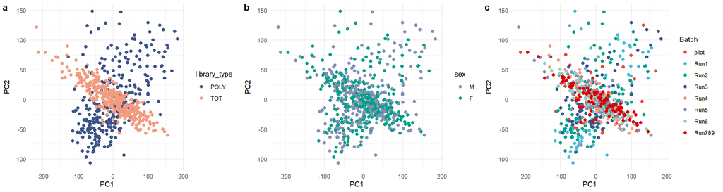

```r
npg_colors <- pal_npg()(n = 2)
npg_colors <- rev(npg_colors)
npg_colors3 <- pal_npg()(n = 5)
npg_colors3 <- npg_colors3[4:5]
npg_colors6 <- pal_npg()(n = 9)
npg_colors6 <- npg_colors6[c(6,3)]
npg_colors6L <- pal_npg()(n = 6)
npg_colors8 <- pal_npg()(n = 8)

plot_pcs <- function(data, pc_x, pc_y, color_var, point_colors) {
  ggplot(data, aes(x = !!sym(pc_x), y = !!sym(pc_y), color = !!sym(color_var))) +
    geom_point(aes(color = factor(!!sym(color_var))), size = 2) +  # Adjust size as needed
    scale_color_manual(values = point_colors) +  # Apply custom colors from the palette
    theme_minimal()
}

p1 <- plot_pcs(scores_meta, "PC1", "PC2", "library_type", npg_colors3)
p2 <- plot_pcs(scores_meta, "PC1", "PC2", "sex", npg_colors6)
p3 <- plot_pcs(scores_meta, "PC1", "PC2", "Batch", npg_colors8)

p_15 <- ggarrange(p1,p2,p3,labels = c("a", "b", "c"),ncol = 3, nrow = 1)
print(p_15)
```

# 4. Supplementary Figure S14. Selection of principal components for differential gene expression analysis.

To correct for batch effects, RNA PCs were carefully selected by first checking correlation between top 10 PCs with other covariates in the DEG models: we checked Pearson’s linear correlation between RNA PCs with continuous variables, and Kruskal–Wallis’s test between RNA PCs and categorical variables.

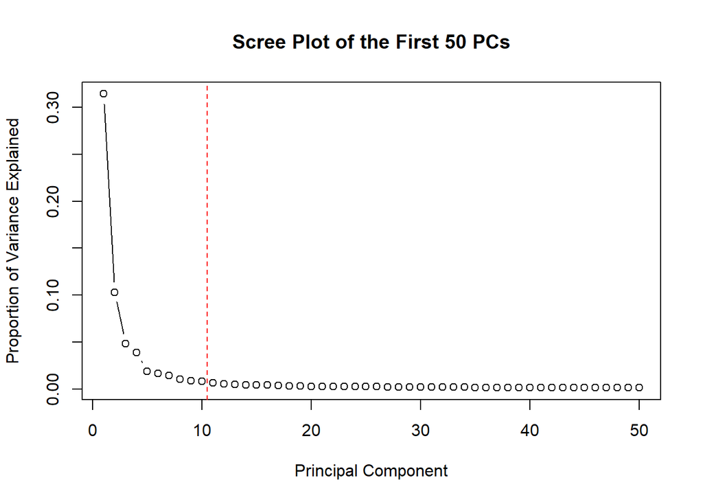

```r
# Regress out subject type, sex, age
design <- model.matrix(~ 1 + subject_type + sex + age_at_sample_date, data = meta)

residual_exprs <- apply(lcpm_filtered, 1, function(gene_expr) {
  fit <- lm.fit(design, gene_expr)
  residuals(fit)
})

pca_result <- prcomp(residual_exprs, center = TRUE, scale. = TRUE)
scores <- pca_result$x

# Extract PC1 to PC10
RNA_PC1 <- scores[, 1]
RNA_PC2 <- scores[, 2]
RNA_PC3 <- scores[, 3]
RNA_PC4 <- scores[, 4]
RNA_PC5 <- scores[, 5]
RNA_PC6 <- scores[, 6]
RNA_PC7 <- scores[, 7]
RNA_PC8 <- scores[, 8]
RNA_PC9 <- scores[, 9]
RNA_PC10 <- scores[, 10]

scores_df<-as.data.frame(scores)
scores_df$rn<-rownames(scores_df)
scores_meta<-left_join(scores_df,meta,by=c("rn"="Sample"))

par(mfrow=c(1,1))

pca_summary <- summary(pca_result)

variance_explained <- pca_summary$importance[2, 1:50]
plot(variance_explained, type = "b", xlab = "Principal Component",
    ylab = "Proportion of Variance Explained",
    main = "Scree Plot of the First 50 PCs")
abline(v=10.5, col="red", lty="dashed")
```

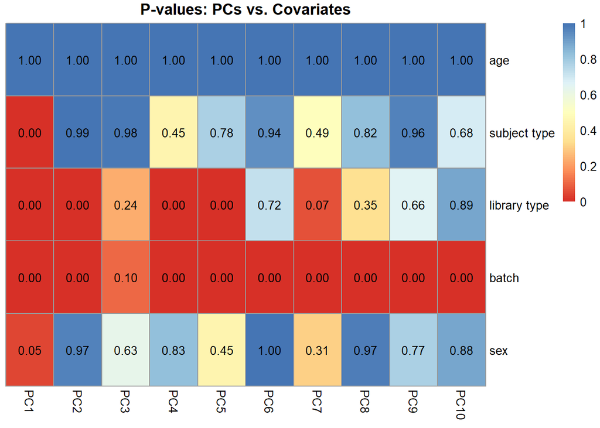

```r
pc_cols   <- paste0("PC", 1:10)
cont_var  <- "age_at_sample_date"
cat_vars  <- c("subject_type", "library_type", "Batch", "sex")

row_names <- c("age", "subject type", "library type", "batch", "sex")
mat_p     <- matrix(NA,
                    nrow = length(row_names),
                    ncol = length(pc_cols),
                    dimnames = list(row_names, pc_cols))

# continuous: Pearson
for (pc in pc_cols) {
  tt <- cor.test(scores_meta[[cont_var]], scores_meta[[pc]], method = "pearson")
  mat_p["age", pc] <- tt$p.value
}

# categorical: Kruskal–Wallis
for (i in seq_along(cat_vars)) {
  var <- cat_vars[i]
  rn  <- row_names[i+1]
  for (pc in pc_cols) {
    kk <- kruskal.test(scores_meta[[pc]] ~ scores_meta[[var]])
    mat_p[rn, pc] <- kk$p.value
  }
}

cols <- colorRampPalette(brewer.pal(n = 7, name = "RdYlBu"))(100)
pheatmap(mat_p, color = cols,breaks = seq(0, 1, length.out = 101), cluster_rows = FALSE, cluster_cols = FALSE, display_numbers = T, number_color = "black", fontsize_number = 10, main = "P-values: PCs vs. Covariates")
```

We also performed logistic regression adjusting for other covariates. PC1, PC3 are correlated with case control status after multiple test correction. PC1 is associated with case control status for the primary analysis (the model not fully adjusting for cell type proportions).

```r
# Functions
extract_p_values_glm <- function(base_model_name, num_models, data) {
  p_values_list <- list()
  for (i in 1:num_models) {
    # Construct the predictor variable dynamically (e.g., PC1, PC2, ..., PC10)
    pc_variable <- paste("PC", i, sep = "")
    # Construct the model formula dynamically
    formula <- as.formula(paste("subject_type ~", pc_variable, "+ age_at_sample_date + sex + all_PC1 + all_PC2 + all_PC3 + all_PC4 + Batch + library_type"))
    model <- glm(formula, data = data, family = binomial)
    model_summary <- summary(model)
    model_p_values <- coef(model_summary)[, "Pr(>|z|)"]
    p_values_list[[paste(base_model_name, i, sep = "")]] <- model_p_values
  }
  p_values_df <- as.data.frame(do.call(cbind, p_values_list))
  predictor_names <- names(coef(model))
  rownames(p_values_df) <- predictor_names
  return(p_values_df)
}

extract_p_values_glm_CellPro <- function(base_model_name, num_models, data) {
  p_values_list <- list()

  for (i in 1:num_models) {
    pc_variable <- paste("PC", i, sep = "")
    formula <- as.formula(paste("subject_type ~", pc_variable, "+ age_at_sample_date + sex + all_PC1 + all_PC2 + all_PC3 + all_PC4 +  CD8T_DNA + Mono_DNA + NK_DNA + Bcell_DNA + Neu_DNA + Batch + library_type"))
    model <- glm(formula, data = data, family = binomial)
    model_summary <- summary(model)
    model_p_values <- coef(model_summary)[, "Pr(>|z|)"]
    p_values_list[[paste(base_model_name, i, sep = "")]] <- model_p_values
  }
  p_values_df <- as.data.frame(do.call(cbind, p_values_list))
  predictor_names <- names(coef(model))
  rownames(p_values_df) <- predictor_names

  return(p_values_df)
}

display_p_values_table <- function(p_values_df) {
  datatable(p_values_df,
            extensions = 'Buttons',
            options = list(
              dom = 'Blfrtip',
              buttons = list('copy', 'csv', 'excel', 'pdf', 'print'),
              pageLength = 10,
              autoWidth = TRUE,
              ordering = TRUE # This enables interactive column sorting
            )) %>%
    formatStyle(
      columns = names(p_values_df),
      color = 'black',
      backgroundColor = 'white'
    )
}

p_values_df_glm<-extract_p_values_glm("glm_pc", 10, scores_meta)
row.names(p_values_df_glm)[2]<-"pc_i"
adjust.pvalue<-p.adjust(p_values_df_glm[2,],method="bonferroni")
result<-rbind(p_values_df_glm,adjust.pvalue)
row.names(result)[dim(result)[1]]<-"adj.p"

p_values_df_glm_CellPro<-extract_p_values_glm_CellPro("glm_pc", 10, scores_meta)
row.names(p_values_df_glm_CellPro)[2]<-"pc_i"
adjust.pvalue<-p.adjust(p_values_df_glm_CellPro[2,],method="bonferroni")
result_CellPro<-rbind(p_values_df_glm_CellPro,adjust.pvalue)
row.names(result_CellPro)[dim(result_CellPro)[1]]<-"adj.p"
```

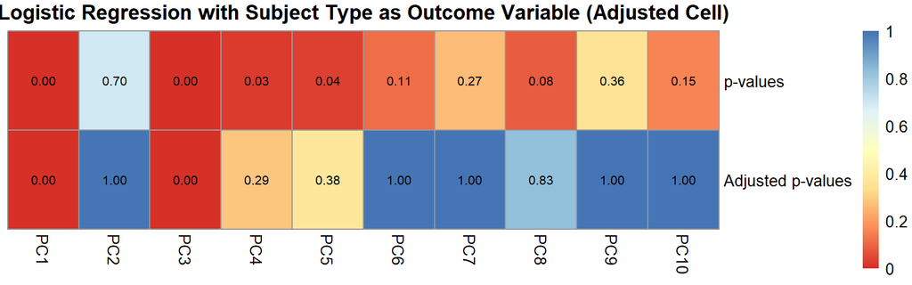

```r
colnames(result_CellPro)<-c("PC1","PC2","PC3","PC4","PC5","PC6","PC7","PC8","PC9","PC10")
result_CellPro2<-result_CellPro[c(2,22),]
rownames(result_CellPro2)<-c("p-values","Adjusted p-values")
pheatmap(result_CellPro2, cluster_rows = FALSE, cluster_cols = FALSE, color = cols, main="Logistic Regression with Subject Type as Outcome Variable (Adjusted Cell)", display_numbers = T, number_color="black")
```

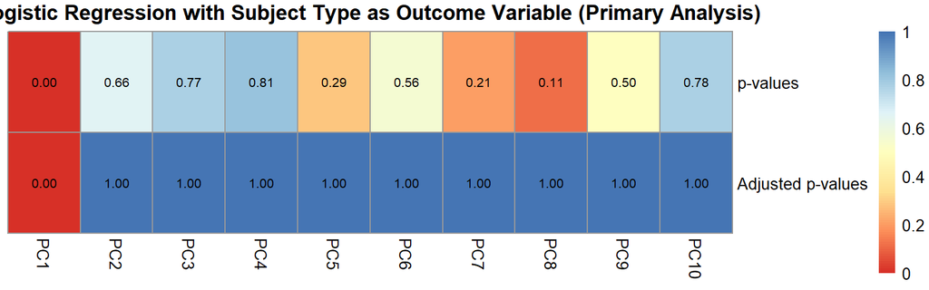

```r
colnames(result)<-c("PC1","PC2","PC3","PC4","PC5","PC6","PC7","PC8","PC9","PC10")
result2<-result[c(2,17),]
rownames(result2)<-c("p-values","Adjusted p-values")
pheatmap(result2, cluster_rows = FALSE, cluster_cols = FALSE, color = cols, main="Logistic Regression with Subject Type as Outcome Variable (Primary Analysis)", display_numbers = T, number_color="black")
```

# 5. Add 8 PCs to DEG model #1 adjust for cell types. Add 9 PCs to whole blood DEG model #2 “primary analysis”. Check PCA on residuals.

We add PCs2,4,5,6,7,8,9,10 to the DEG model #1 (adjust for cell type compositions) to remove unknown variance.

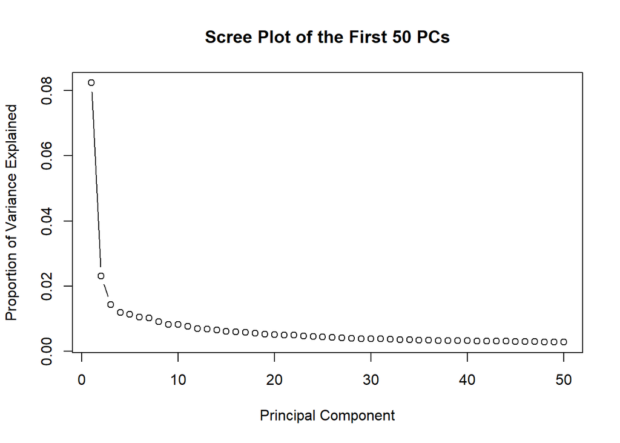

```r
runPCAResiduals <- function(design,
                            expr_mat,
                            meta_df,
                            join_by = c("rn" = "Sample"),
                            n_pcs = 50) {

  residuals_mat <- apply(expr_mat, 1, function(gene_expr) {
    fit <- lm.fit(design, gene_expr)
    residuals(fit)
  })

  pca_res <- prcomp(residuals_mat, center = TRUE, scale. = TRUE)

  var_exp <- summary(pca_res)$importance[2, seq_len(n_pcs)]
  plot(var_exp, type = "b",
       xlab = "Principal Component",
       ylab = "Proportion of Variance Explained",
       main = paste0("Scree Plot of the First ", n_pcs, " PCs"))

  scores_df <- as.data.frame(pca_res$x)
  scores_df$rn <- rownames(scores_df)
  scores_meta2 <- dplyr::left_join(scores_df, meta_df, by = join_by)
  return(scores_meta2)
}

design1 <- model.matrix(~ 1 + age_at_sample_date + sex + CD8T_DNA + Mono_DNA + NK_DNA + Bcell_DNA + Neu_DNA + all_PC1 + all_PC2 + all_PC3 + all_PC4 + Batch + library_type +PC2+PC4+PC5+PC6 + PC7+PC8 + PC9 + PC10, data = scores_meta)

scores_meta1 <- runPCAResiduals(design1,
                                lcpm_filtered,
                                meta,
                                join_by = c("rn" = "Sample"),
                                n_pcs = 50)
```

Response Figure R2. PCA plots for DEGs analysis adjusted for cell proportions.

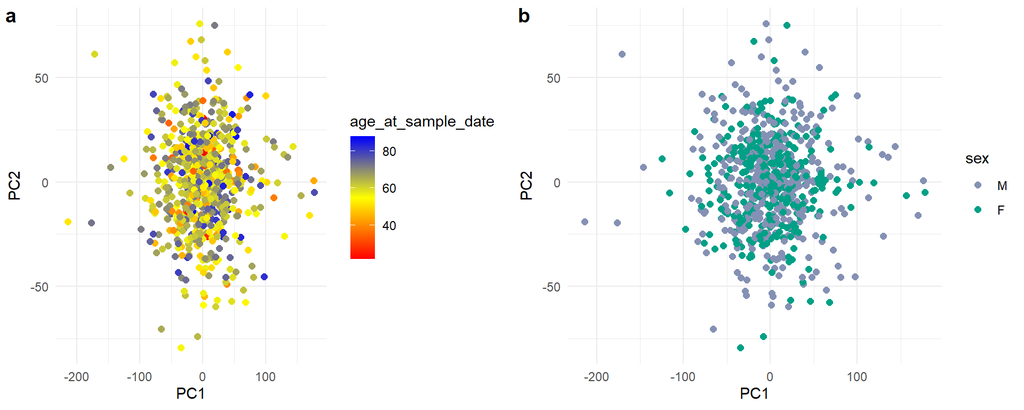

```r
npg_colors8 <- pal_npg()(n = 8)
plot_pcs_gradient <- function(data, pc_x, pc_y, color_var, custom_palette) {
  ggplot(data, aes(x = !!sym(pc_x), y = !!sym(pc_y), color = !!sym(color_var))) +
    geom_point(size = 2) +  # Adjust size as needed
    scale_color_gradientn(colors = custom_palette)+
    theme_minimal()
}
custom_palette <- colorRampPalette(c("red", "yellow","blue"))(n = 139)

p1 <- plot_pcs_gradient(scores_meta1, "PC1", "PC2", "age_at_sample_date", custom_palette)
p2 <- plot_pcs(scores_meta1, "PC1", "PC2", "sex", npg_colors6)

p_3 <- ggarrange(p1,p2,
                labels = c("a", "b"),
                ncol = 2, nrow = 1)
print(p_3)
```

We add PCs2,3,4,5,6,7,8,9,10 to the DEG model #2 (not adjust for cell type compositions) to remove unknown variance.

```r
design2 <- model.matrix(~ 1 + age_at_sample_date + sex + all_PC1 + all_PC2 + all_PC3 + all_PC4 + Batch + library_type + PC2 + PC3 + PC4 + PC5 + PC6 + PC7 + PC8 + PC9 + PC10, data = scores_meta)

scores_meta2 <- runPCAResiduals(design2,
                                lcpm_filtered,
                                meta,
                                join_by = c("rn" = "Sample"),
                                n_pcs = 50)
```

[figure not shown]

Response Figure R1. PCA plots for primary DEGs analysis.

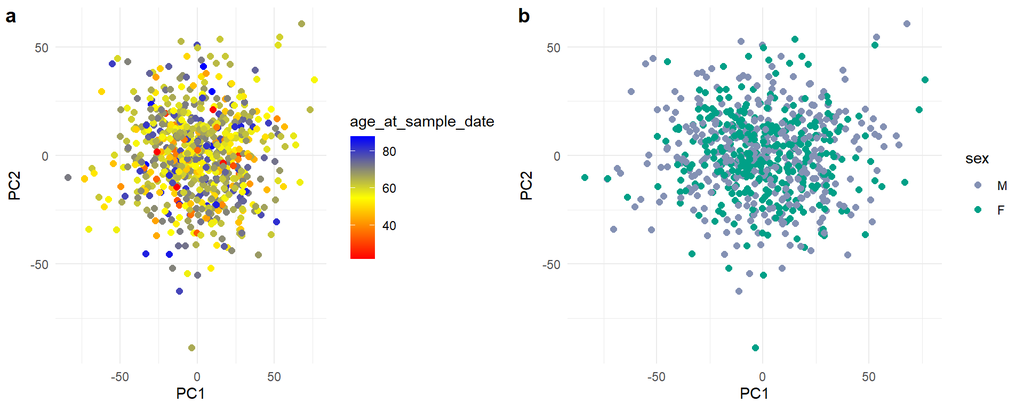

```r
p11 <- plot_pcs_gradient(scores_meta2, "PC1", "PC2", "age_at_sample_date", custom_palette)
p22 <- plot_pcs(scores_meta2, "PC1", "PC2", "sex", npg_colors6)

p_33 <- ggarrange(p11,p22,
                labels = c("a", "b"),
                ncol = 2, nrow = 1)
print(p_33)
```

# 6. Supplementary Figure S14a. Heatmap of Pearson’s correlation results between RNA PCs and cell type proportions. Legend and box colors indicate Pearson’s correlation coefficients; box numbers indicate Bonferroni-adjusted p-values.

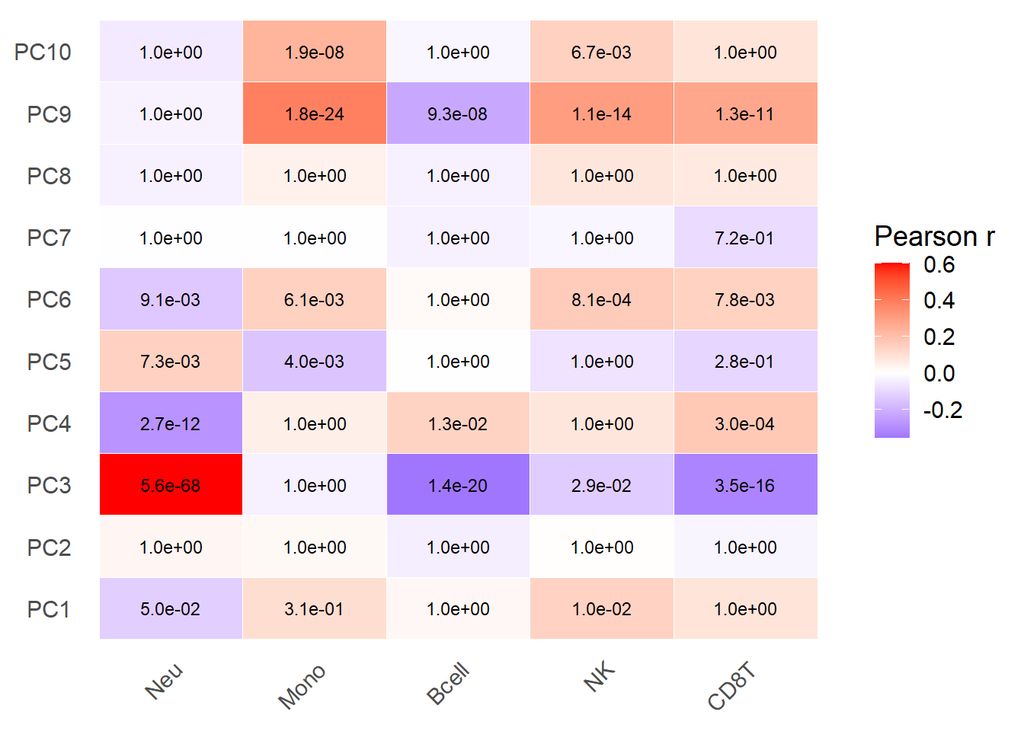

```r
# define PCs and cell types
pcs        <- paste0("PC", 1:10)
cell_types <- c("Neu","Mono","Bcell","NK","CD8T")

# 1. compute raw cor and p-values
cor_mat <- sapply(cell_types, function(ct) {
  sapply(pcs, function(pc) {
    cor(scores_meta[[paste0(ct, "_DNA")]], scores_meta[[pc]], use="complete.obs")
  })
})
pval_mat <- sapply(cell_types, function(ct) {
  sapply(pcs, function(pc) {
    cor.test(scores_meta[[paste0(ct, "_DNA")]], scores_meta[[pc]])$p.value
  })
})
rownames(cor_mat)  <- pcs
rownames(pval_mat) <- pcs

# 2. Bonferroni adjust across all 50 tests
p_adj_mat <- matrix(
  p.adjust(as.vector(pval_mat), method = "bonferroni"),
  nrow = nrow(pval_mat), ncol = ncol(pval_mat),
  dimnames = dimnames(pval_mat)
)

# 3. combine into a long data frame
heatmap_df <- as.data.frame(cor_mat) %>%
  rownames_to_column("PC") %>%
  pivot_longer(-PC, names_to = "CellType", values_to = "r") %>%
  mutate(
    p_adj = as.vector(t(p_adj_mat)),
    p_label = format(p_adj, scientific = TRUE, digits = 2)
  )

heatmap_df <- heatmap_df %>%
  mutate(
    PC       = factor(PC, levels = paste0("PC", 1:10)),
    CellType = factor(CellType, levels = cell_types)    # if you also want a specific cell‐type order
  )

# write.table(heatmap_df, file="PC_CellType_corr_v2.txt", quote=F, sep="\t", row.names=F)

# 4. plot heatmap of r, annotate with p_adj
ggplot(heatmap_df, aes(x = CellType, y = PC, fill = r)) +
  geom_tile(color = "white") +
  geom_text(aes(label = p_label), size = 3) +
  scale_fill_gradient2(
    low  = "blue",
    mid  = "white",
    high = "red",
    midpoint = 0,
    name = "Pearson r"
  ) +
  labs(x = NULL, y = NULL) +
  theme_minimal(base_size = 14) +
  theme(
    axis.text.x = element_text(angle = 45, hjust = 1),
    panel.grid  = element_blank()
  )
```

```r
selected_df <- heatmap_df %>%
  filter(
    abs(r)   > 0.25,
    p_adj    < 0.05
  )
# write.table(selected_df, file="PC_CellType_corr_selv2.txt", quote=F, sep="\t", row.names=F)
```

# 7. Include PCs in DEG models, check DEG w/ and w/o adjusting for cell type compositions.

```r
run_limma_voom_PC <- function(df,meta) {
  dm<-df[, match(meta$Sample,colnames(df))]
  genelen <- read.table("featurecounts_length.txt", sep="\t", header=T, stringsAsFactors = F)
  gene_anno <- read.table("geneID_genename_biotypes.txt", sep="\t", header=F, stringsAsFactors = F)
  colnames(gene_anno) <- c("geneid", "gene_symbol","biotype")
  genes <- left_join(gene_anno, genelen, by = c("geneid" = "gene_id"))
  target<-row.names(df)
  genes <- genes[match(target,genes$geneid),]
  samplenames <- factor(meta$Sample)
  group <- factor(meta$subject_type, levels = c("control", "case"))
  dm3<-as.matrix(dm)
  y <- DGEList(counts = dm3, group=group, genes=genes, samples=samplenames)
  y3 <- calcNormFactors(y, method = "TMM")
  tmm <- cpm(y3)
  tmmLog2<-log2(tmm+1)

  #DE
  sex<-factor(meta$sex)
  batch<-factor(meta$Batch, levels = c("Run5","pilot","Run1","Run2","Run3","Run4","Run6", "Run789"))
  prep<-factor(meta$library_type)
  age<-meta$age_at_sample_date
  CD4T<-meta$`CD4T_DNA`
  CD8T<-meta$`CD8T_DNA`
  Monocyte<-meta$`Mono_DNA`
  NK<-meta$`NK_DNA`
  BCells<-meta$`Bcell_DNA`
  Neutrophil<-meta$`Neu_DNA`
  PC1<-meta$all_PC1
  PC2<-meta$all_PC2
  PC3<-meta$all_PC3
  PC4<-meta$all_PC4
  RNA_PC1 <- meta$PC1
  RNA_PC2 <- meta$PC2
  RNA_PC3 <- meta$PC3
  RNA_PC4 <- meta$PC4
  RNA_PC5 <- meta$PC5
  RNA_PC6 <- meta$PC6
  RNA_PC7 <- meta$PC7
  RNA_PC8 <- meta$PC8
  RNA_PC9 <- meta$PC9
  RNA_PC10 <- meta$PC10
  design <- model.matrix(~group+age+sex+CD8T+Monocyte+NK+BCells+Neutrophil+PC1+PC2+PC3+PC4+batch+prep+RNA_PC2+RNA_PC4+RNA_PC5+RNA_PC6+RNA_PC7+RNA_PC8+RNA_PC9+RNA_PC10)
  v <- voom(y3, design, plot=F)
  vfit <- lmFit(v, design)
  efit <- eBayes(vfit)
  pval.df <- as.data.frame(efit$p.value)
  fdr.df <- apply(pval.df, 2, p.adjust, "fdr")
  sigGeneNum_byFDR.df <- as.data.frame(apply(fdr.df, 2, function(x){sum(x < 0.05)}))
  tmp = topTable(efit, coef=2, n=Inf)
  tmp = tmp[order(tmp$adj.P.Val),]
  deg<-tmp
  deg$diffexpressed <- "NO"
  deg$diffexpressed[deg$logFC > 0 & deg$adj.P.Val < 0.05] <- "UP"
  deg$diffexpressed[deg$logFC < 0 & deg$adj.P.Val < 0.05] <- "DOWN"
  return(list(df=df,meta=meta,tmm=tmm,efit=efit,design=design,vfit=vfit,sigGeneNum_byFDR.df=sigGeneNum_byFDR.df,deg=deg))
}

run_limma_voom_sex_stratified_PC <- function(df,meta) {
  dm<-df[, match(meta$Sample,colnames(df))]
  genelen <- read.table("featurecounts_length.txt", sep="\t", header=T, stringsAsFactors = F)
  gene_anno <- read.table("geneID_genename_biotypes.txt", sep="\t", header=F, stringsAsFactors = F)
  colnames(gene_anno) <- c("geneid", "gene_symbol","biotype")
  genes <- left_join(gene_anno, genelen, by = c("geneid" = "gene_id"))
  target<-row.names(df)
  genes <- genes[match(target,genes$geneid),]
  samplenames <- factor(meta$Sample)
  group <- factor(meta$subject_type, levels = c("control", "case"))
  dm3<-as.matrix(dm)
  y <- DGEList(counts = dm3, group=group, genes=genes, samples=samplenames)
  y3 <- calcNormFactors(y, method = "TMM")
  tmm <- cpm(y3)
  tmmLog2<-log2(tmm+1)

  #DE
  batch<-factor(meta$Batch, levels = c("Run5","pilot","Run1","Run2","Run3","Run4","Run6", "Run789"))
  prep<-factor(meta$library_type)
  age<-meta$age_at_sample_date
  CD4T<-meta$`CD4T_DNA`
  CD8T<-meta$`CD8T_DNA`
  Monocyte<-meta$`Mono_DNA`
  NK<-meta$`NK_DNA`
  BCells<-meta$`Bcell_DNA`
  Neutrophil<-meta$`Neu_DNA`
  PC1<-meta$all_PC1
  PC2<-meta$all_PC2
  PC3<-meta$all_PC3
  PC4<-meta$all_PC4
  RNA_PC1 <- meta$PC1
  RNA_PC2 <- meta$PC2
  RNA_PC3 <- meta$PC3
  RNA_PC4 <- meta$PC4
  RNA_PC5 <- meta$PC5
  RNA_PC6 <- meta$PC6
  RNA_PC7 <- meta$PC7
  RNA_PC8 <- meta$PC8
  RNA_PC9 <- meta$PC9
  RNA_PC10 <- meta$PC10
  design <- model.matrix(~group+age+CD8T+Monocyte+NK+BCells+Neutrophil+PC1+PC2+PC3+PC4+batch+prep+RNA_PC2+RNA_PC4+RNA_PC5+RNA_PC6+RNA_PC7+RNA_PC8+RNA_PC9+RNA_PC10)
  v <- voom(y3, design, plot=F)
  vfit <- lmFit(v, design)
  efit <- eBayes(vfit)
  pval.df <- as.data.frame(efit$p.value)
  fdr.df <- apply(pval.df, 2, p.adjust, "fdr")
  sigGeneNum_byFDR.df <- as.data.frame(apply(fdr.df, 2, function(x){sum(x < 0.05)}))
  tmp = topTable(efit, coef=2, n=Inf)
  tmp = tmp[order(tmp$adj.P.Val),]
  deg<-tmp
  deg$diffexpressed <- "NO"
  deg$diffexpressed[deg$logFC > 0 & deg$adj.P.Val < 0.05] <- "UP"
  deg$diffexpressed[deg$logFC < 0 & deg$adj.P.Val < 0.05] <- "DOWN"
  return(list(df=df,meta=meta,tmm=tmm,efit=efit,design=design,vfit=vfit,sigGeneNum_byFDR.df=sigGeneNum_byFDR.df,deg=deg))
}

colnames(scores_meta)[695]<-"Sample"
scores_meta_m<-filter(scores_meta,sex=="M")
scores_meta_f<-filter(scores_meta,sex=="F")
df_filtered<-s4_filtered[["data"]]
dm_filtered<-dm[match(df_filtered$Gene,row.names(dm)),]
all.list<-run_limma_voom_PC(dm_filtered,meta=scores_meta)
male.list<-run_limma_voom_sex_stratified_PC(dm_filtered,meta=scores_meta_m)
female.list<-run_limma_voom_sex_stratified_PC(dm_filtered,meta=scores_meta_f)

source('./CaseVSControl/sample694/RNA_PC_regress/volcano_plot.R')
PC8_p_value<-extract_p_value(all.list[["deg"]])
PC8_all<-generate_volcano_plot_p(all.list[["deg"]],PC8_p_value, plot_title="All w/Cell Adj", y_lim = 50)
PC8_male_p_value<-extract_p_value(male.list[["deg"]])
PC8_male<-generate_volcano_plot_p(male.list[["deg"]],PC8_male_p_value, plot_title="Males w/Cell Adj",y_lim=50)
PC8_female_p_value<-extract_p_value(female.list[["deg"]])
PC8_female<-generate_volcano_plot_p(female.list[["deg"]],PC8_female_p_value, plot_title="Females w/Cell Adj", y_lim = 50)
p_PC8_3 <- ggarrange(PC8_all, PC8_male, PC8_female, ncol = 3)
# print(p_PC8_3)
```

To compare DEGs between primary analysis and with cell proportion adjustment.

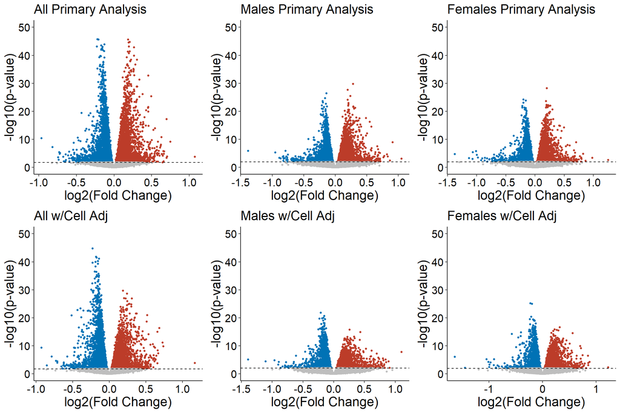

```r
run_limma_voom_PC_nocellpro <- function(df,meta) {
  dm<-df[, match(meta$Sample,colnames(df))]
  genelen <- read.table("featurecounts_length.txt", sep="\t", header=T, stringsAsFactors = F)
  gene_anno <- read.table("geneID_genename_biotypes.txt", sep="\t", header=F, stringsAsFactors = F)
  colnames(gene_anno) <- c("geneid", "gene_symbol","biotype")
  genes <- left_join(gene_anno, genelen, by = c("geneid" = "gene_id"))
  target<-row.names(df)
  genes <- genes[match(target,genes$geneid),]
  samplenames <- factor(meta$Sample)
  group <- factor(meta$subject_type, levels = c("control", "case"))
  dm3<-as.matrix(dm)
  y <- DGEList(counts = dm3, group=group, genes=genes, samples=samplenames)
  y3 <- calcNormFactors(y, method = "TMM")
  tmm <- cpm(y3)
  tmmLog2<-log2(tmm+1)

  #DE
  sex<-factor(meta$sex)
  batch<-factor(meta$Batch, levels = c("Run5","pilot","Run1","Run2","Run3","Run4","Run6", "Run789"))
  prep<-factor(meta$library_type)
  age<-meta$age_at_sample_date
  CD4T<-meta$`CD4T_DNA`
  CD8T<-meta$`CD8T_DNA`
  Monocyte<-meta$`Mono_DNA`
  NK<-meta$`NK_DNA`
  BCells<-meta$`Bcell_DNA`
  Neutrophil<-meta$`Neu_DNA`
  PC1<-meta$all_PC1
  PC2<-meta$all_PC2
  PC3<-meta$all_PC3
  PC4<-meta$all_PC4
  RNA_PC1 <- meta$PC1
  RNA_PC2 <- meta$PC2
  RNA_PC3 <- meta$PC3
  RNA_PC4 <- meta$PC4
  RNA_PC5 <- meta$PC5
  RNA_PC6 <- meta$PC6
  RNA_PC7 <- meta$PC7
  RNA_PC8 <- meta$PC8
  RNA_PC9 <- meta$PC9
  RNA_PC10 <- meta$PC10
  design <- model.matrix(~group+age+sex+PC1+PC2+PC3+PC4+batch+prep+RNA_PC2+RNA_PC3+RNA_PC4+RNA_PC5+RNA_PC6+RNA_PC7+RNA_PC8+RNA_PC9+RNA_PC10)
  v <- voom(y3, design, plot=F)
  vfit <- lmFit(v, design)
  efit <- eBayes(vfit)
  pval.df <- as.data.frame(efit$p.value)
  fdr.df <- apply(pval.df, 2, p.adjust, "fdr")
  sigGeneNum_byFDR.df <- as.data.frame(apply(fdr.df, 2, function(x){sum(x < 0.05)}))
  tmp = topTable(efit, coef=2, n=Inf)
  tmp = tmp[order(tmp$adj.P.Val),]
  deg<-tmp
  deg$diffexpressed <- "NO"
  deg$diffexpressed[deg$logFC > 0 & deg$adj.P.Val < 0.05] <- "UP"
  deg$diffexpressed[deg$logFC < 0 & deg$adj.P.Val < 0.05] <- "DOWN"
  return(list(df=df,meta=meta,tmm=tmm,efit=efit,design=design,vfit=vfit,sigGeneNum_byFDR.df=sigGeneNum_byFDR.df,deg=deg))
}

run_limma_voom_sex_stratified_PC_nocellpro <- function(df,meta) {
  dm<-df[, match(meta$Sample,colnames(df))]
  genelen <- read.table("featurecounts_length.txt", sep="\t", header=T, stringsAsFactors = F)
  gene_anno <- read.table("geneID_genename_biotypes.txt", sep="\t", header=F, stringsAsFactors = F)
  colnames(gene_anno) <- c("geneid", "gene_symbol","biotype")
  genes <- left_join(gene_anno, genelen, by = c("geneid" = "gene_id"))
  target<-row.names(df)
  genes <- genes[match(target,genes$geneid),]
  samplenames <- factor(meta$Sample)
  group <- factor(meta$subject_type, levels = c("control", "case"))
  dm3<-as.matrix(dm)
  y <- DGEList(counts = dm3, group=group, genes=genes, samples=samplenames)
  y3 <- calcNormFactors(y, method = "TMM")
  tmm <- cpm(y3)
  tmmLog2<-log2(tmm+1)

  #DE
  batch<-factor(meta$Batch, levels = c("Run5","pilot","Run1","Run2","Run3","Run4","Run6", "Run789"))
  prep<-factor(meta$library_type)
  age<-meta$age_at_sample_date
  CD4T<-meta$`CD4T_DNA`
  CD8T<-meta$`CD8T_DNA`
  Monocyte<-meta$`Mono_DNA`
  NK<-meta$`NK_DNA`
  BCells<-meta$`Bcell_DNA`
  Neutrophil<-meta$`Neu_DNA`
  PC1<-meta$all_PC1
  PC2<-meta$all_PC2
  PC3<-meta$all_PC3
  PC4<-meta$all_PC4
  RNA_PC1 <- meta$PC1
  RNA_PC2 <- meta$PC2
  RNA_PC3 <- meta$PC3
  RNA_PC4 <- meta$PC4
  RNA_PC5 <- meta$PC5
  RNA_PC6 <- meta$PC6
  RNA_PC7 <- meta$PC7
  RNA_PC8 <- meta$PC8
  RNA_PC9 <- meta$PC9
  RNA_PC10 <- meta$PC10
  design <- model.matrix(~group+age+PC1+PC2+PC3+PC4+batch+prep+RNA_PC2+RNA_PC3+RNA_PC4+RNA_PC5+RNA_PC6+RNA_PC7+RNA_PC8+RNA_PC9+RNA_PC10)
  v <- voom(y3, design, plot=F)
  vfit <- lmFit(v, design)
  efit <- eBayes(vfit)
  pval.df <- as.data.frame(efit$p.value)
  fdr.df <- apply(pval.df, 2, p.adjust, "fdr")
  sigGeneNum_byFDR.df <- as.data.frame(apply(fdr.df, 2, function(x){sum(x < 0.05)}))
  tmp = topTable(efit, coef=2, n=Inf)
  tmp = tmp[order(tmp$adj.P.Val),]
  deg<-tmp
  deg$diffexpressed <- "NO"
  deg$diffexpressed[deg$logFC > 0 & deg$adj.P.Val < 0.05] <- "UP"
  deg$diffexpressed[deg$logFC < 0 & deg$adj.P.Val < 0.05] <- "DOWN"
  return(list(df=df,meta=meta,tmm=tmm,efit=efit,design=design,vfit=vfit,sigGeneNum_byFDR.df=sigGeneNum_byFDR.df,deg=deg))
}

colnames(scores_meta)[695]<-"Sample"
scores_meta_m<-filter(scores_meta,sex=="M")
scores_meta_f<-filter(scores_meta,sex=="F")
df_filtered<-s4_filtered[["data"]]
dm_filtered<-dm[match(df_filtered$Gene,row.names(dm)),]
NoCellPro.PC9.all.list<-run_limma_voom_PC_nocellpro(dm_filtered,meta=scores_meta)
NoCellPro.PC9.male.list<-run_limma_voom_sex_stratified_PC_nocellpro(dm_filtered,meta=scores_meta_m)
NoCellPro.PC9.female.list<-run_limma_voom_sex_stratified_PC_nocellpro(dm_filtered,meta=scores_meta_f)

source('./CaseVSControl/sample694/RNA_PC_regress/volcano_plot.R')
NoCellPro_PC9_p_value<-extract_p_value(NoCellPro.PC9.all.list[["deg"]])
NoCellPro_PC9_all<-generate_volcano_plot_p(NoCellPro.PC9.all.list[["deg"]],NoCellPro_PC9_p_value, plot_title="All Primary Analysis", y_lim = 50)
NoCellPro_PC9_male_p_value<-extract_p_value(NoCellPro.PC9.male.list[["deg"]])
NoCellPro_PC9_male<-generate_volcano_plot_p(NoCellPro.PC9.male.list[["deg"]],NoCellPro_PC9_male_p_value, plot_title="Males Primary Analysis",y_lim=50)
NoCellPro_PC9_female_p_value<-extract_p_value(NoCellPro.PC9.female.list[["deg"]])
NoCellPro_PC9_female<-generate_volcano_plot_p(NoCellPro.PC9.female.list[["deg"]],NoCellPro_PC9_female_p_value, plot_title="Females Primary Analysis", y_lim = 50)
NoCellPro_p_PC9_6 <- ggarrange(NoCellPro_PC9_all, NoCellPro_PC9_male, NoCellPro_PC9_female, PC8_all, PC8_male, PC8_female, ncol = 3, nrow=2)
print(NoCellPro_p_PC9_6)
```

# 8. Supplementary Figure S16. Overlap of differentially expressed genes (DEGs) in ALS versus control blood samples in primary analyses and analyses adjusted for cell proportions.

```r
PC8_f_df <- female.list[["deg"]]
PC8_m_df <- male.list[["deg"]]
PC8_all_df <- all.list[["deg"]]
NoCellPro.PC9.all_df<-NoCellPro.PC9.all.list[["deg"]]
NoCellPro.PC9.male_df<-NoCellPro.PC9.male.list[["deg"]]
NoCellPro.PC9.female_df<-NoCellPro.PC9.female.list[["deg"]]
PC8_deg_df<-PC8_all_df
PC8_deg_df$diffexpressed<-"NO"
PC8_deg_df$diffexpressed[PC8_deg_df$logFC > 0.1 & PC8_deg_df$adj.P.Val < 0.01] <- "UP"
PC8_deg_df$diffexpressed[PC8_deg_df$logFC < -0.1 & PC8_deg_df$adj.P.Val < 0.01] <- "DOWN"
table(PC8_deg_df$diffexpressed)
```

```
##
##  DOWN    NO    UP
##  1650 18883  1799
```

```r
NoCellPro_PC9_deg_df<-NoCellPro.PC9.all_df
NoCellPro_PC9_deg_df$diffexpressed<-"NO"
NoCellPro_PC9_deg_df$diffexpressed[NoCellPro_PC9_deg_df$logFC > 0.1 & NoCellPro_PC9_deg_df$adj.P.Val < 0.01] <- "UP"
NoCellPro_PC9_deg_df$diffexpressed[NoCellPro_PC9_deg_df$logFC < -0.1 & NoCellPro_PC9_deg_df$adj.P.Val < 0.01] <- "DOWN"
table(NoCellPro_PC9_deg_df$diffexpressed)
```

```
##
##  DOWN    NO    UP
##  1641 18692  1999
```

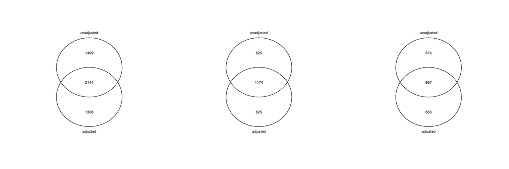

```r
par(mfrow=c(1,3))
compare.list<-list()
compare.list[["adjusted"]]<-unique(PC8_deg_df[which(PC8_deg_df$diffexpressed!="NO"),"geneid"])
compare.list[["unadjusted"]]<-unique(NoCellPro_PC9_deg_df[which(NoCellPro_PC9_deg_df$diffexpressed!="NO"),"geneid"])
venn(compare.list)

compare.list2<-list()
compare.list2[["adjusted"]]<-PC8_deg_df[which(PC8_deg_df$diffexpressed=="UP"),"geneid"]
compare.list2[["unadjusted"]]<-NoCellPro_PC9_deg_df[which(NoCellPro_PC9_deg_df$diffexpressed=="UP"),"geneid"]
venn(compare.list2)

compare.list3<-list()
compare.list3[["adjusted"]]<-PC8_deg_df[which(PC8_deg_df$diffexpressed=="DOWN"),"geneid"]
compare.list3[["unadjusted"]]<-NoCellPro_PC9_deg_df[which(NoCellPro_PC9_deg_df$diffexpressed=="DOWN"),"geneid"]
venn(compare.list3)
```

```r
fisher_overlap_summary <- function(a, b, c, d) {
  # a: DEG in both adjusted and primary
  # b: DEG in adjusted only
  # c: DEG in primary only
  # d: Not DEG in either

  # Create contingency table
  table_matrix <- matrix(c(a, b, c, d), nrow = 2, byrow = TRUE,
                         dimnames = list(
                           "Adjusted_DEG" = c("DEG", "Not_DEG"),
                           "Primary_DEG"  = c("DEG", "Not_DEG")
                         ))

  # Fisher's exact test
  fisher_result <- fisher.test(table_matrix)

  # Jaccard index (overlap score)
  jaccard_index <- a / (a + b + c)

  # Output summary
  list(
    table = table_matrix,
    p_value = fisher_result$p.value,
    odds_ratio = fisher_result$estimate,
    conf_int = fisher_result$conf.int,
    jaccard_index = jaccard_index
  )
}

# Input values
a <- 2141  # DEG in both
b <- 1308  # DEG in adjusted only
c <- 1499  # DEG in primary only
d <- 17383 # Not DEG in either

# Run function
result <- fisher_overlap_summary(a, b, c, d)

# View results
print(result)
```

```
## $table
##             Primary_DEG
## Adjusted_DEG  DEG Not_DEG
##      DEG     2141    1308
##      Not_DEG 1499   17383
##
## $p_value
## [1] 0
##
## $odds_ratio
## odds ratio
##   18.98209
##
## $conf_int
## [1] 17.38570 20.72764
## attr(,"conf.level")
## [1] 0.95
##
## $jaccard_index
## [1] 0.4327001
```

```r
# Input values
a <- 1174  # DEG in both
b <- 625  # DEG in adjusted only
c <- 825  # DEG in primary only
d <- 22332-a-b-c # Not DEG in either

# Run function
result_up <- fisher_overlap_summary(a, b, c, d)

# View results
print(result_up)
```

```
## $table
##             Primary_DEG
## Adjusted_DEG  DEG Not_DEG
##      DEG     1174     625
##      Not_DEG  825   19708
##
## $p_value
## [1] 0
##
## $odds_ratio
## odds ratio
##   44.82229
##
## $conf_int
## [1] 39.76339 50.65159
## attr(,"conf.level")
## [1] 0.95
##
## $jaccard_index
## [1] 0.4474085
```

```r
# Input values
a <- 967  # DEG in both
b <- 683  # DEG in adjusted only
c <- 674  # DEG in primary only
d <- 22332-a-b-c # Not DEG in either

# Run function
result_down <- fisher_overlap_summary(a, b, c, d)

# View results
print(result_down)
```

```
## $table
##             Primary_DEG
## Adjusted_DEG DEG Not_DEG
##      DEG     967     683
##      Not_DEG 674   20008
##
## $p_value
## [1] 0
##
## $odds_ratio
## odds ratio
##   42.00494
##
## $conf_int
## [1] 37.05797 47.73917
## attr(,"conf.level")
## [1] 0.95
##
## $jaccard_index
## [1] 0.4160929
```

# 9. PCA check using surrogate variables

```r
load("C:/Users/yuedz/OneDrive - Michigan Medicine/Documents/svobj.rda")
scores_meta3<-cbind.data.frame(scores_meta, svobj$sv)
colnames(scores_meta3)[(ncol(scores_meta3)-1):ncol(scores_meta3)]<-c("SV1", "SV2")
```

```r
design <- model.matrix(~ 1 + age_at_sample_date + sex + CD8T_DNA + Mono_DNA + NK_DNA + Bcell_DNA + Neu_DNA + all_PC1 + all_PC2 + all_PC3 + all_PC4 + SV1+SV2, data = scores_meta3)

residual_exprs <- apply(lcpm_filtered, 1, function(gene_expr) {
  fit <- lm.fit(design, gene_expr)
  residuals(fit)
})

pca_result <- prcomp(residual_exprs, center = TRUE, scale. = TRUE)
scores <- pca_result$x
scores_df<-as.data.frame(scores)
scores_df$rn<-rownames(scores_df)
scores_meta4<-left_join(scores_df,meta,by=c("rn"="Sample"))
par(mfrow=c(1,1))

pca_summary <- summary(pca_result)
variance_explained <- pca_summary$importance[2, 1:50]
# plot(variance_explained, type = "b", xlab = "Principal Component",
#     ylab = "Proportion of Variance Explained",
#     main = "Scree Plot of the First 50 PCs")
```

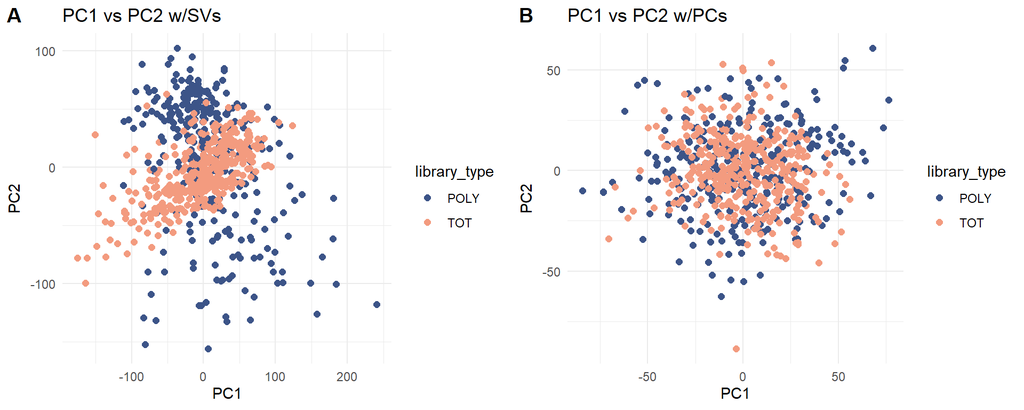

```r
plot_pcs <- function(data, pc_x, pc_y, color_var, point_colors) {
  ggplot(data, aes(x = !!sym(pc_x), y = !!sym(pc_y), color = !!sym(color_var))) +
    geom_point(aes(color = factor(!!sym(color_var))), size = 2) +  # Adjust size as needed
    scale_color_manual(values = point_colors) +  # Apply custom colors from the palette
    labs(x = pc_x, y = pc_y, title = paste(pc_x, "vs", pc_y, "w/SVs"), color = color_var) +
    theme_minimal()
}

plot_pcs2 <- function(data, pc_x, pc_y, color_var, point_colors) {
  ggplot(data, aes(x = !!sym(pc_x), y = !!sym(pc_y), color = !!sym(color_var))) +
    geom_point(aes(color = factor(!!sym(color_var))), size = 2) +  # Adjust size as needed
    scale_color_manual(values = point_colors) +  # Apply custom colors from the palette
    labs(x = pc_x, y = pc_y, title = paste(pc_x, "vs", pc_y, "w/PCs"), color = color_var) +
    theme_minimal()
}

p11_SVA <- plot_pcs(scores_meta4, "PC1", "PC2", "library_type", npg_colors3)
p11_PC <- plot_pcs2(scores_meta2, "PC1", "PC2", "library_type", npg_colors3)


p_S1 <- ggarrange(p11_SVA,p11_PC,
                labels = c("A", "B"),
                ncol = 2, nrow = 1)
print(p_S1)
```

# 10. List for wet lab qPCR validation

Starting with no cell type proportion adjustment DEG list: selection criteria: 1) FDR<0.01; 2) logFC>0.2; 3) AveExpr > 0; 4) Sig in both male and female; 5) Sig in both w/ and w/o cell proportion adjustment; 6) Sig in Wilcox test.

```r
NoCellPro.PC8.all.df<-NoCellPro.PC9.all.list[["deg"]]
NoCellPro.PC8.male.df<-NoCellPro.PC9.male.list[["deg"]]
NoCellPro.PC8.female.df<-NoCellPro.PC9.female.list[["deg"]]
# 1) FDR<0.01; 2) logFC>0.2; 3) AveExpr > 0
deg.select<- NoCellPro.PC8.all.df %>% filter(adj.P.Val<0.01) %>% filter(abs(logFC)>0.2) %>% filter(AveExpr>0)

# 4) add male_p, female_p, male_FDR, female_FDR
deg.select2<-deg.select%>%left_join(NoCellPro.PC8.male.df[,c("geneid", "logFC","AveExpr","P.Value","adj.P.Val")], by="geneid" )%>%left_join(NoCellPro.PC8.female.df[,c("geneid", "logFC","AveExpr","P.Value","adj.P.Val")], by="geneid" )
colnames(deg.select2)<- gsub("\\.x", ".all", colnames(deg.select2))
colnames(deg.select2)<- gsub("\\.y", ".male", colnames(deg.select2))
colnames(deg.select2)[16:19]<-c("logFC.female","AveExpr.female","P.Value.female","adj.P.Val.female")

# 5) add CellPro_p, CellPro_male_p, CellPro_female_p, CellPro_FDR, CellPro_male_FDR, CellPro_female_FDR
deg.select2b<-deg.select2%>% left_join(PC8_all_df[,c("geneid", "logFC","AveExpr","P.Value","adj.P.Val")], by="geneid" )
deg.select2c<-deg.select2b%>% left_join(PC8_m_df[,c("geneid", "logFC","AveExpr","P.Value","adj.P.Val")], by="geneid" )
deg.select2d<-deg.select2c%>% left_join(PC8_f_df[,c("geneid", "logFC","AveExpr","P.Value","adj.P.Val")], by="geneid" )
colnames(deg.select2d)<- gsub("\\.x", ".all.CellPro", colnames(deg.select2d))
colnames(deg.select2d)<- gsub("\\.y", ".male.CellPro", colnames(deg.select2d))
colnames(deg.select2d)[28:31]<-c("logFC.female.CellPro","AveExpr.female.CellPro","P.Value.female.CellPro","adj.P.Val.female.CellPro")

# 6) Wilcox test
AddWilcox <- function(meta, lcpm_filtered, deg.PCR9) {
  if (!all(colnames(lcpm_filtered) == meta$Sample)) {
    stop("Sample names do not match!")
  }
  design <- model.matrix(~ 1 + Batch + library_type + PC2 + PC4 + PC5, data = meta)
  residual_exprs <- apply(lcpm_filtered, 1, function(gene_expr) {
    fit <- lm.fit(design, gene_expr)
    residuals(fit)
  })
  residual_exprs <- t(residual_exprs)
  residual_df <- as.data.frame(residual_exprs)
  residual_df$geneid <- row.names(residual_df)

  meta <- meta[order(meta$subject_type, decreasing = TRUE), ]
  num_cases <- sum(meta$subject_type == "case")
  num_controls <- sum(meta$subject_type == "control")

  residual_df_order <- residual_df[, match(meta$Sample, colnames(residual_df))]
  residual_df_order$geneid <- row.names(residual_df_order)

  deg.PCR12 <- dplyr::left_join(deg.PCR9, residual_df_order, by = c("geneid"))

  deg.PCR12$wilcox_p <- NA

  deg.PCR12_up <- dplyr::filter(deg.PCR12, diffexpressed == 'UP')
  deg.PCR12_down <- dplyr::filter(deg.PCR12, diffexpressed == 'DOWN')

  for (i in 1:nrow(deg.PCR12)) {
    gene_values <- deg.PCR12[i, (ncol(deg.PCR9)+1):(ncol(deg.PCR12)-1)]
    control_values <- t(gene_values[(num_cases+1):ncol(gene_values)])
    case_values <- t(gene_values[1:num_cases])

    test_result <- wilcox.test(control_values, case_values)

    deg.PCR12$wilcox_p[i] <- test_result$p.value
  }

  # Wilcoxon test for upregulated genes
  for (i in 1:nrow(deg.PCR12_up)) {
    gene_values <- deg.PCR12_up[i, (ncol(deg.PCR9)+1):(ncol(deg.PCR12_up)-1)]
    control_values <- t(gene_values[(num_cases+1):ncol(gene_values)])
    case_values <- t(gene_values[1:num_cases])

    test_result <- wilcox.test(control_values, case_values, alternative = "less")
    deg.PCR12_up$wilcox_p[i] <- test_result$p.value
  }

  # Wilcoxon test for downregulated genes
  for (i in 1:nrow(deg.PCR12_down)) {
    gene_values <- deg.PCR12_down[i, (ncol(deg.PCR9)+1):(ncol(deg.PCR12_down)-1)]
    control_values <- t(gene_values[(num_cases+1):ncol(gene_values)])
    case_values <- t(gene_values[1:num_cases])

    test_result <- wilcox.test(control_values, case_values, alternative = "greater")
    deg.PCR12_down$wilcox_p[i] <- test_result$p.value
  }

  deg.PCR12 <- dplyr::bind_rows(deg.PCR12_up, deg.PCR12_down)

  deg.PCR12.save <- deg.PCR12[, c(1:ncol(deg.PCR9), ncol(deg.PCR12))]
  deg.PCR12.save$wilcox_adjust_Bon <- p.adjust(deg.PCR12.save$wilcox_p, method = "bonferroni")

  return(deg.PCR12.save)
}

deg.select.w<-AddWilcox(scores_meta, lcpm_filtered, deg.select2d)


# 7) add Literature notation
DEG_2011_ALS_S1 <- read_excel("~/Project/ALS/paper/Microarray analysis of peripheral blood lymphocytes from ALS patients and the SAFE detection of the KEGG ALS pathway/DEG_2011_ALS-S1.XLS")
n397_DEG_2018 <- read_excel("~/Project/ALS/paper/2019_ALS_transcriptome/2018 n397 paper/n397_DEG_2018.xlsx")
DEG_up_list <- read_excel("~/Project/ALS/paper/2019_ALS_transcriptome/DEG_list.xlsx",sheet = "(A) Inc DEGs")
DEG_down_list <- read_excel("~/Project/ALS/paper/2019_ALS_transcriptome/DEG_list.xlsx",sheet = "(B) Dec DEGs")
DEG_2023<-read_excel("~/Project/ALS/paper/2023_ALS_transcriptome/DEG_2023.xlsx")
DEG_2023<-filter(DEG_2023,padj.BH<0.05)

DEG_2011<-DEG_2011_ALS_S1 #Symbol
DEG_2018<-n397_DEG_2018 #Symbol
DEG_2019<-rbind.data.frame(DEG_up_list,DEG_down_list) #Symbol
DEG_2023<-DEG_2023 #Gene_Symbol

deg.select.w$Literature <- ""

# Function to append literature if a gene symbol is found in a specific dataframe
append_literature <- function(df, gene_col, literature_name, target_df) {
  # Check if each gene symbol in target_df is in df
  in_literature <- target_df$gene_symbol %in% df[[gene_col]]
  new_df<-target_df
  # Append the literature name to the Literature column where appropriate
  new_df$Literature[in_literature] <- ifelse(nchar(target_df$Literature[in_literature]) == 0,
                                                literature_name,
                                                paste(target_df$Literature[in_literature], literature_name, sep = ","))
  return(new_df)
}

# Check and append literature for each DEG dataframe
deg.select4<-append_literature(DEG_2011, "Symbol", "DEG_2011", deg.select.w)
deg.select5<-append_literature(DEG_2018, "Symbol", "DEG_2018", deg.select4)
deg.select6<-append_literature(DEG_2019, "Symbol", "DEG_2019", deg.select5)
deg.select7<-append_literature(DEG_2023, "Gene_Symbol", "DEG_2023", deg.select6)
```